# EDA Assignment 4

# For Pokemondata

We are going to check the data spread of HP data in pokemondata set.

```r
Pokemondata <- read.csv("https://docs.google.com/spreadsheets/d/1ni9fGCOfnUd3BYuggKm_jttRh8DHpQFgLXHiZYDPiCg/pub?output=csv")
```

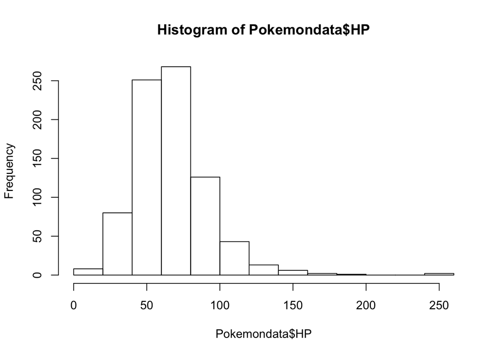

```r
hist(Pokemondata$HP)
```

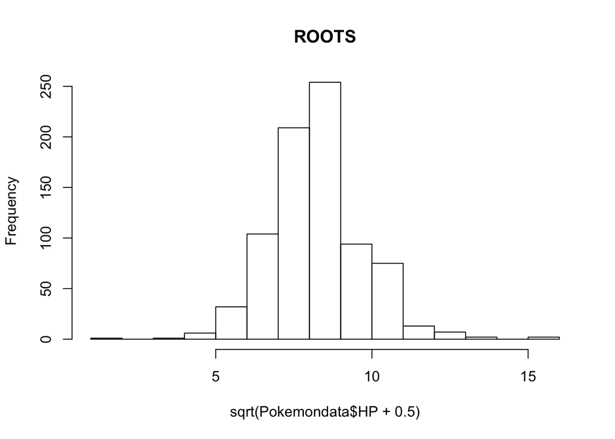

```r
par(mfrow=c(1, 1))
hist(sqrt(Pokemondata$HP + 0.5), main="ROOTS")
```

```r
lval(Pokemondata$HP)
```

```
##   depth   lo  hi   mids spreads
## M 400.5 65.0  65  65.00     0.0
## H 200.5 50.0  80  65.00    30.0
## E 100.5 44.0  98  71.00    54.0
## D  50.5 39.5 106  72.75    66.5
## C  25.5 33.0 120  76.50    87.0
## B  13.0 30.0 135  82.50   105.0
## A   7.0 20.0 150  85.00   130.0
## Z   4.0 20.0 170  95.00   150.0
## Y   2.5 15.0 220 117.50   205.0
## X   1.0  1.0 255 128.00   254.0
```

There is right skewedness in the data.

```r
letter.values <- lval(Pokemondata$HP)
letter.values$mids
```

```
##  [1]  65.00  65.00  71.00  72.75  76.50  82.50  85.00  95.00 117.50 128.00
```

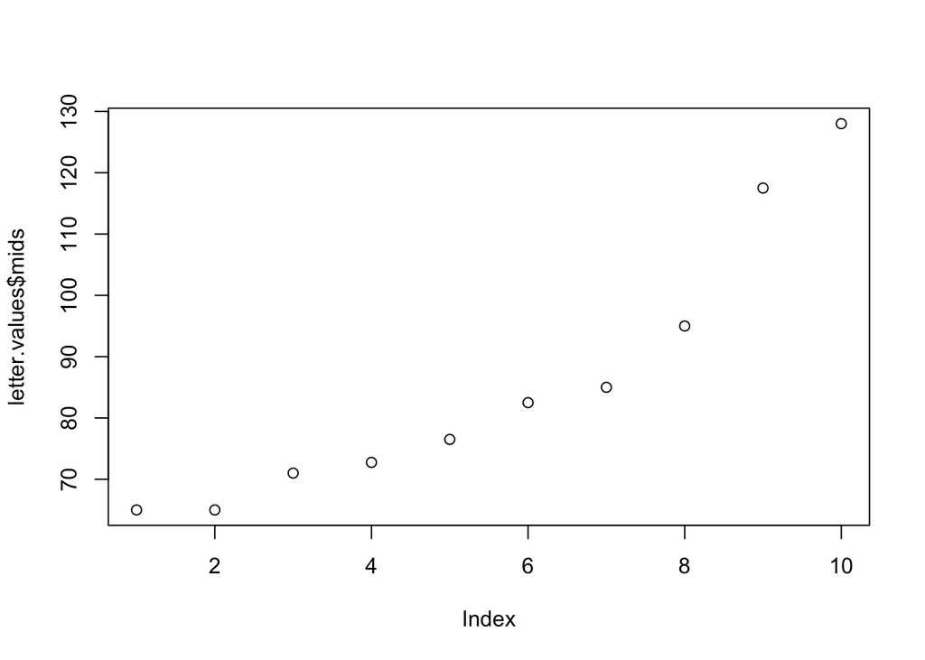

```r
plot(letter.values$mids)
```

You can see the right skewness since this sequence is in creasing.

```r
#take roots
roots <- sqrt(Pokemondata$HP)
aplpack::stem.leaf(roots)
```

```
## 1 | 2: represents 1.2
##  leaf unit: 0.1
##             n: 800
## LO: 1 3.16227766016838
##      8     4* | 444444
##            4. |
##     24     5* | 0024444444444444
##     40     5. | 5999999999999999
##     92     6* | 0011111122333333333333333333333333333333333333334444
##    144     6. | 5556666666777777777777777777777777777777777777777999
##    257     7* | 00000000000000000000000000000000000000000000000000000000000000000012222333344444444444444444444444444444444444444
##    353     7. | 555666666666666777777777777777777777777777777777777777777777777777777777777777777788888888888999
##   (135)    8* | 000000000000000000000000000000000000000000000000000011111111222222233333333333333333333333333333333333333333333333333333333333444444444
##    312     8. | 55556666666666666666666666666666666666666666666666667777777788888888888888889999999999999999999999999999999999999999999
##    193     9* | 00011111222222222222222222222223444444444444444444444444444444
##    131     9. | 55555555777777777777777777777789
##     99    10* | 000000000000000000000000000000000111122222222222222233334444444444
##     33    10. | 567777999
##     24    11* | 00111122444
##     13    11. | 68
##     11    12* | 02222
## HI: 12.6491106406735 12.8452325786651 13.0384048104053 13.7840487520902 15.8113883008419 15.9687194226713
```

```r
root.lv <- lval(roots)
root.lv
```

```
##   depth       lo        hi     mids   spreads
## M 400.5 8.062258  8.062258 8.062258  0.000000
## H 200.5 7.071068  8.944272 8.007670  1.873204
## E 100.5 6.633250  9.899366 8.266308  3.266117
## D  50.5 6.284777 10.295630 8.290203  4.010853
## C  25.5 5.741922 10.954451 8.348187  5.212529
## B  13.0 5.477226 11.618950 8.548088  6.141724
## A   7.0 4.472136 12.247449 8.359792  7.775313
## Z   4.0 4.472136 13.038405 8.755270  8.566269
## Y   2.5 3.817207 14.797719 9.307463 10.980512
## X   1.0 1.000000 15.968719 8.484360 14.968719
```

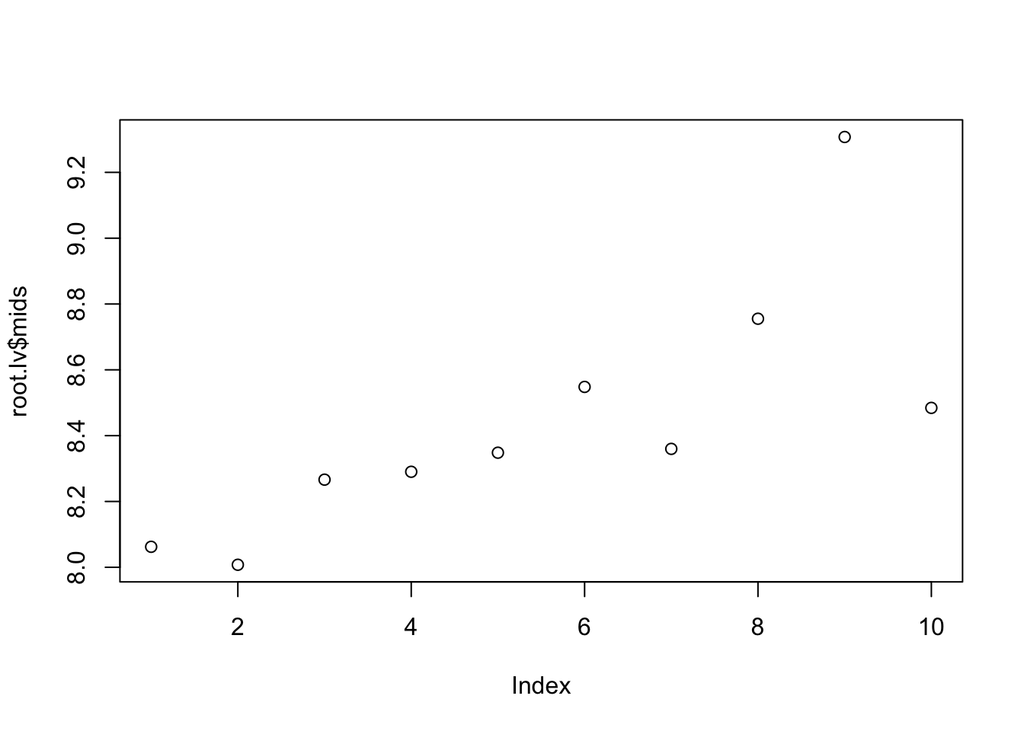

```r
plot(root.lv$mids)
```

```r
#take log
logs <- log(Pokemondata$HP)
aplpack::stem.leaf(logs)
```

```
## 1 | 2: represents 0.12
##  leaf unit: 0.01
##             n: 800
## LO: 0 2.30258509299405 2.99573227355399 2.99573227355399 2.99573227355399 2.99573227355399 2.99573227355399 2.99573227355399
##    10    32 | 11
##    11    33 | 3
##    25    34 | 00000000000003
##    41    35 | 5555555555555558
##    88    36 | 13333336688888888888888888888888888888888888888
##   102    37 | 11136668888888
##   147    38 | 000000000000000000000000000000000000002777999
##   219    39 | 111111111111111111111111111111111111111111111111111111111111111355778888
##   339    40 | 000000000000000000000000000000000000024446666667777779999999999999999999999999999999999999999999999999999999999999999999
##   (69)   41 | 111122222224445555557777777777777777777777777777777777777777777777888
##   392    42 | 000001111111334444444444444444444444444444444444444444444444444444444446666777779999
##   308    43 | 00000111111111111111111111111111111111111111111133333444555555555666666688888888888888888888888888888888888888888889
##   192    44 | 0011133444444444444444444455557888999999999999999999999999999
##   131    45 | 11111112555555555555555555555579
##    99    46 | 000000000000000000000000000000001333455555555556666688889
##    42    47 | 000000000034445888
##    24    48 | 11222233666
##    13    49 | 046
##    10    50 | 11117
##     5    51 | 03
## HI: 5.24702407216049 5.52146091786225 5.54126354515843
```

```r
logs.lv <- lval(logs)
logs.lv
```

```
##   depth       lo       hi     mids   spreads
## M 400.5 4.174387 4.174387 4.174387 0.0000000
## H 200.5 3.912023 4.382027 4.147025 0.4700036
## E 100.5 3.784190 4.584915 4.184553 0.8007258
## D  50.5 3.676221 4.663439 4.169830 0.9872185
## C  25.5 3.494668 4.787492 4.141080 1.2928241
## B  13.0 3.401197 4.905275 4.153236 1.5040774
## A   7.0 2.995732 5.010635 4.003184 2.0149030
## Z   4.0 2.995732 5.135798 4.065765 2.1400662
## Y   2.5 2.649159 5.384242 4.016701 2.7350838
## X   1.0 0.000000 5.541264 2.770632 5.5412635
```

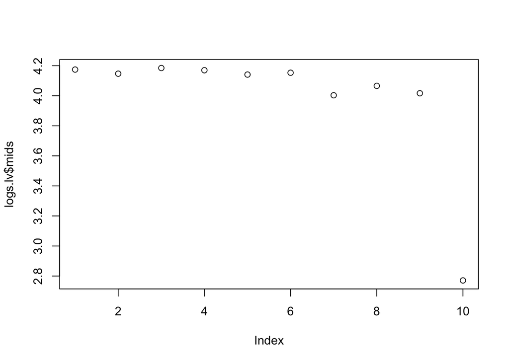

```r
plot(logs.lv$mids)
```

```r
#if take p = −1/2     -1/sqrt(lake$Area) Further investigation
recroots <- - 1 / sqrt(Pokemondata$HP)
aplpack::stem.leaf(recroots)
```

```
## 1 | 2: represents 0.012
##  leaf unit: 0.001
##             n: 800
## LO: -1 -0.316227766016838 -0.223606797749979 -0.223606797749979 -0.223606797749979 -0.223606797749979 -0.223606797749979 -0.223606797749979 -0.2 -0.2
##    11    -18. | 8
##    24    -18* | 2222222222222
##    25    -17. | 9
##          -17* |
##    41    -16. | 9999999999999996
##    50    -16* | 422222200
##    91    -15. | 88888888888888888888888888888888888888666
##   102    -15* | 42220000000
##   141    -14. | 999999999999999999999999999999999999997
##   211    -14* | 4442221111111111111111111111111111111111111111111111111111111111111110
##   219    -13. | 88776666
##   272    -13* | 44444444444444444444444444444444444443222111111000000
##   359    -12. | 999999999999999999999999999999999999999999999999999999999999999999988887777777555555555
##   (63)   -12* | 444444444444444444444444444444444444444444444433322222111111100
##   378    -11. | 9999999999999999999999999999999999999999999999999999999998888777777777666665555555555555555555555555555555555555555555
##   260    -11* | 4444433333333333322222221111111111111111111111111111111111111111111100
##   190    -10. | 99999888888888888888888877776555555555555555555555555555555
##   131    -10* | 4444444422222222222222222222221000000000000000000000000000000000
##    67     -9. | 9888877777777777777766665555555555
##    33     -9* | 43333211100
##    22     -8. | 9999997776
##    12     -8* | 431111
##     6     -7. | 976
##     3     -7* | 2
## HI: -0.0632455532033676 -0.062622429108515
```

```r
recroots.lv <- lval(recroots)
recroots.lv
```

```
##   depth         lo          hi       mids    spreads
## M 400.5 -0.1240347 -0.12403473 -0.1240347 0.00000000
## H 200.5 -0.1414214 -0.11180340 -0.1266124 0.02961796
## E 100.5 -0.1507557 -0.10101920 -0.1258874 0.04973647
## D  50.5 -0.1591210 -0.09712859 -0.1281248 0.06199243
## C  25.5 -0.1743181 -0.09128709 -0.1328026 0.08303098
## B  13.0 -0.1825742 -0.08606630 -0.1343202 0.09650789
## A   7.0 -0.2236068 -0.08164966 -0.1526282 0.14195714
## Z   4.0 -0.2236068 -0.07669650 -0.1501516 0.14691030
## Y   2.5 -0.2699173 -0.06789659 -0.1689069 0.20202069
## X   1.0 -1.0000000 -0.06262243 -0.5313112 0.93737757
```

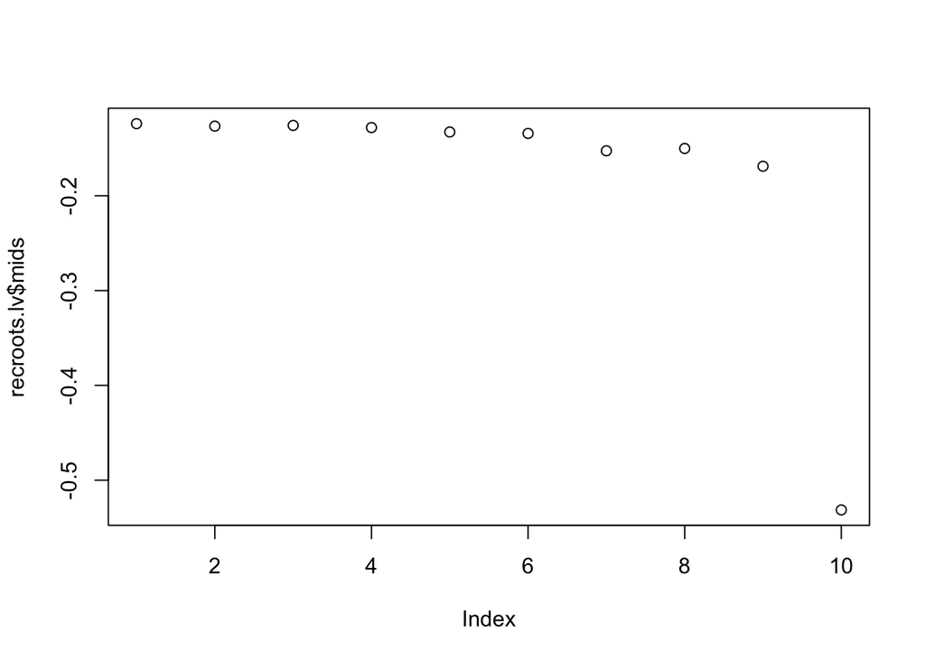

```r
plot(recroots.lv$mids)
```

```r
hinkley(roots)
```

```
##          h
## 0.06844136
```

```r
hinkley(logs)
```

```
##            h
## -0.006773119
```

```r
hinkley(recroots)
```

```
##          h
## -0.1021364
```

Taking roots is the best reexpression to me. However, there are many outliers next to both side of whiskers. Looking at the values of d in Hinkley’s quick method, the correct reexpression appears to be between p=.5 and p=0, although the value closest to 0 corresponds to the log reexpression.

Therefore, we are going to take a new power transforation as p=0.2

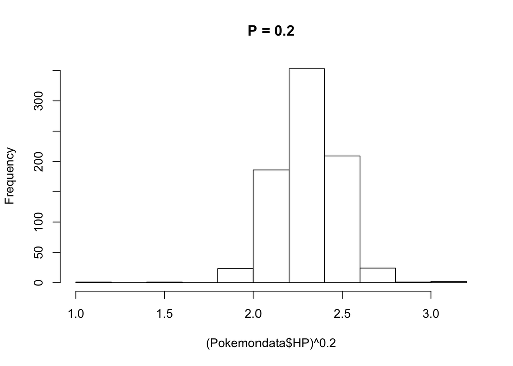

```r
new<-(Pokemondata$HP) ^ 0.2
hist((Pokemondata$HP) ^ 0.2, main="P = 0.2")
```

```r
aplpack::stem.leaf((Pokemondata$HP)^0.2)
```

```
## 1 | 2: represents 0.12
##  leaf unit: 0.01
##             n: 800
## LO: 1 1.58489319246111 1.82056420302608 1.82056420302608 1.82056420302608 1.82056420302608 1.82056420302608 1.82056420302608
##     11    19* | 004
##     25    19. | 77777777777778
##     41    20* | 3333333333333334
##     88    20. | 56666668899999999999999999999999999999999999999
##    140    21* | 0001222333333344444444444444444444444444444444444444
##    211    21. | 56667778888888888888888888888888888888888888888888888888888888888888889
##    260    22* | 0011222222222222222222222222222222222222222223444
##    359    22. | 555555666666666666666666666666666666666666666666666666666666666666666666666666677778888888999999999
##   (124)   23* | 0000000000000000000000000000000000000000000000111111112222222333333333333333333333333333333333333333333333333333333333334444
##    317    23. | 555555555666667777777777777777777777777777777777777777777777778889999999999999999
##    236    24* | 000000000000000000000000000000000000000000001122222333333333333333333333334
##    161    24. | 5555555555555555555555555555556666666788888888888888888888889
##    100    25* | 01111111111111111111111111111111112223333333333344444
##     47    25. | 55555666666666678888
##     27    26* | 00011222233444
##     13    26. | 68
##     11    27* | 02222
##      6    27. | 579
## HI: 2.85595079141473 3.01708816827258 3.02906111670894
```

```r
new.lv <- lval((Pokemondata$HP) ^ 0.2)
new.lv
```

```
##   depth       lo       hi     mids   spreads
## M 400.5 2.304532 2.304532 2.304532 0.0000000
## H 200.5 2.186724 2.402249 2.294487 0.2155247
## E 100.5 2.131526 2.501737 2.316631 0.3702112
## D  50.5 2.085998 2.541331 2.313664 0.4553328
## C  25.5 2.011754 2.605171 2.308463 0.5934167
## B  13.0 1.974350 2.667269 2.320810 0.6929181
## A   7.0 1.820564 2.724070 2.272317 0.9035057
## Z   4.0 1.820564 2.793121 2.306843 0.9725570
## Y   2.5 1.702729 2.936519 2.319624 1.2337908
## X   1.0 1.000000 3.029061 2.014531 2.0290611
```

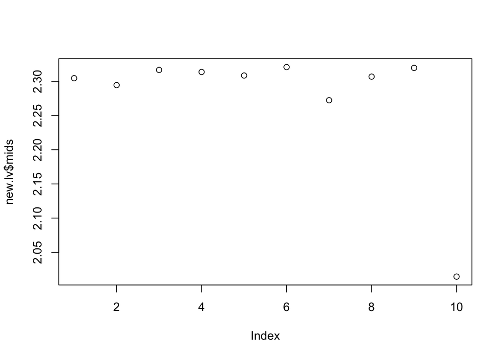

```r
plot(new.lv$mids)
```

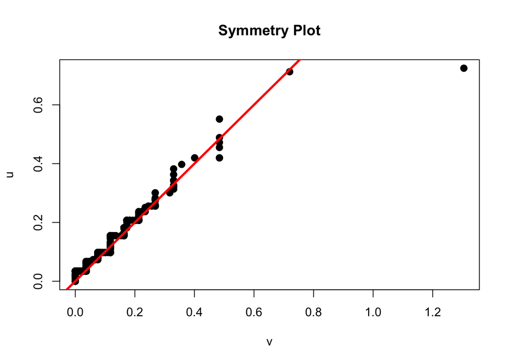

```r
symplot(new)
```

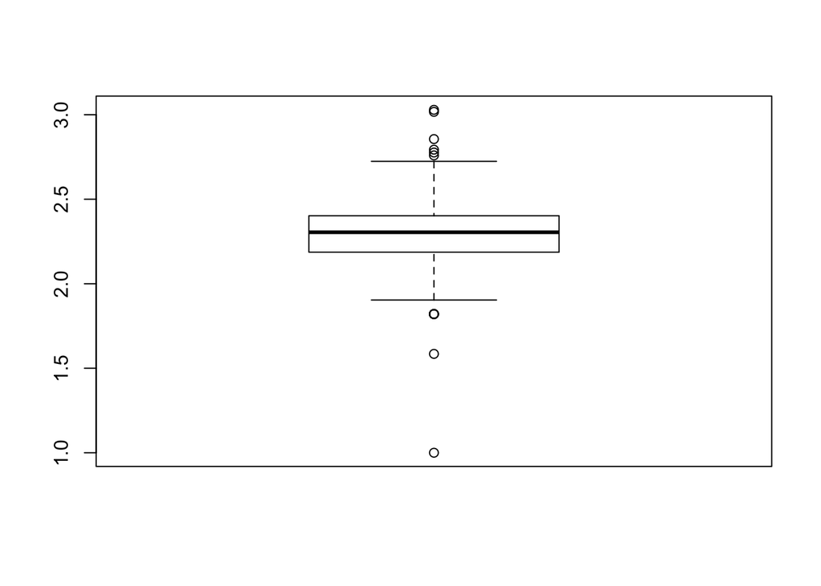

```r
boxplot(new)
```

Looking at a symmetry plot with p=0.2, you can see the data was reexpressed as roughly symmetric. Therefore, (Pokemondata$HP) ^ 0.2 is the best transformation.

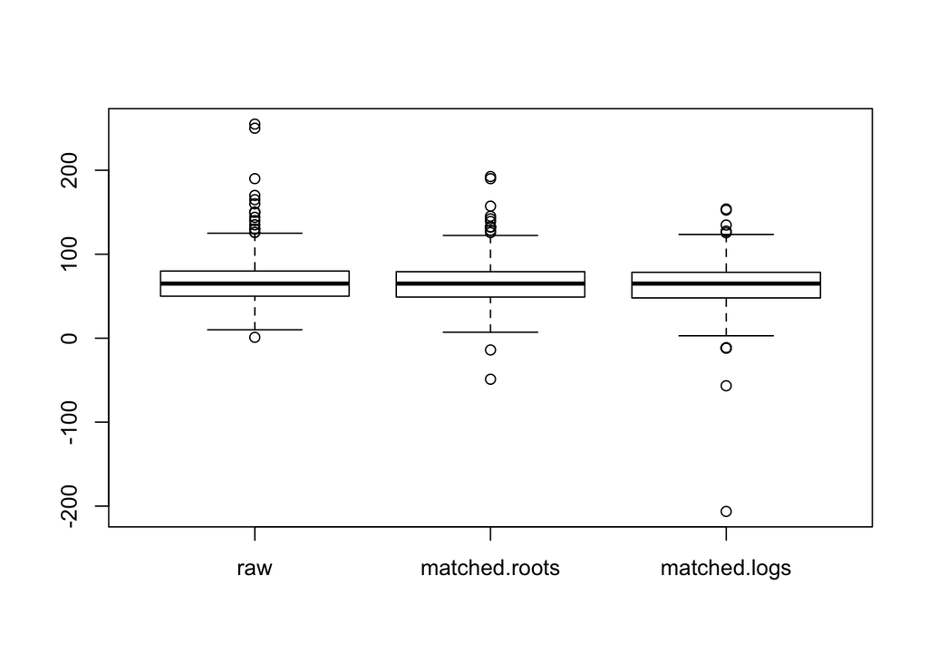

```r
#let x_0 = 65, the medain of the raw data
x_0<-65
matched.roots <- x_0 + (sqrt(Pokemondata$HP) - sqrt(x_0)) / (.5*x_0 ^ (-.5))
matched.logs <- x_0 + (log10(Pokemondata$HP) - log10(x_0)) / (log10(exp(1)) / x_0)

raw <-Pokemondata$HP
matched.roots <- mtrans(raw, 0.5)
matched.logs <- mtrans(raw, 0)
boxplot(data.frame(raw, matched.roots, matched.logs))
```

In conclusion, (Pokemondata$HP) ^ 0.2 is the best transformation since it removes some of outliers and gives the symmetric data distribution.